# Лабораторная работа №4

Реализация основных моделей в агентном подходе.

Разанацуа Сара Естэлл

Российский университет дружбы народов, Москва, Россия

## Цель работы

Создадим агентную модель распространения инфекционного заболевания на основе классической компартментальной модели SIR (Susceptible-InfectiousRecovered). Модель будет реализована с использованием пакета Agents.jl. В отличие от классической модели на дифференциальных уравнениях, агентный подход позволит учесть индивидуальные характеристики, пространственную структуру и стохастичность процессов.

## Задание

1. Создать рабочий каталог для кода.
2. Установить необходимые пакеты.
3. Выполнить предложенный код.
4. Преобразовать код в литературный стиль.
5. Сгенерировать из литературного кода:
- чистый код;
- jupyter notebook;
- документацию в формате Quarto.
6. Выполнить код из jupyter notebook.
7. Интегрировать документацию в формате Quarto в отчёт.
8. Добавить в код в литературном стиле вычисление для набора параметров.
9. Сгенерировать из литературного кода с параметрами:
- чистый код;
- jupyter notebook;
- документацию в формате Quarto.
10. Выполнить код из jupyter notebook с параметрами.
11. Интегрировать документацию с параметрами в формате Quarto в отчёт.
- Результирующие файлы не удаляйте, выложите на git.

# Выполнение лабораторной работы

## Эпидемиологическая модели SIR

- Мы создадим файл src/sir_model.jl. и запустим его.

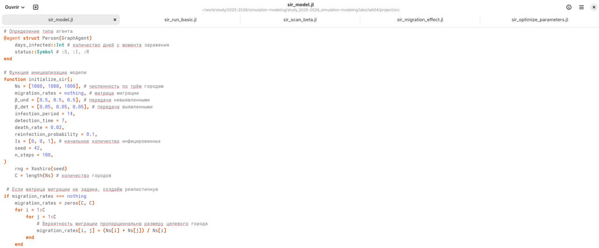

Рис

## Эпидемиологическая модели SIR

- Вывод в консоль.

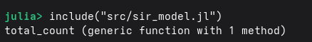

Рис

## Базовый эксперимент

- Запускаем один эксперимент с фиксированными параметрами (по умолчанию) и сохраняем динамику численности агентов. Это служит для проверки работоспособности модели и получения базового понимания эпидемического процесса.

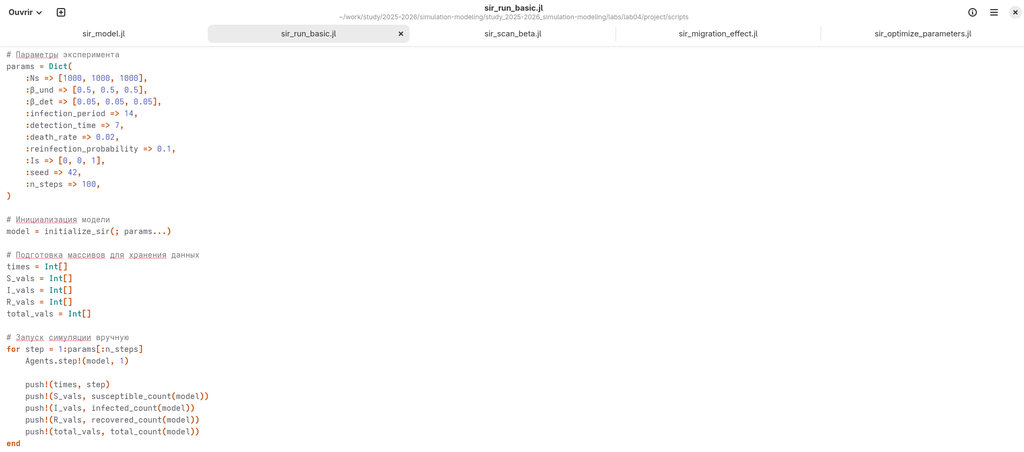

Рис

## Базовый эксперимент

[figure not shown]

Рис

## Базовый эксперимент

- График: plots/sir_basic_dynamics.png — четыре линии: S(t), I(t), R(t) и общая численность. Позволяет визуально оценить пик эпидемии, скорость распространения и влияние смертности.

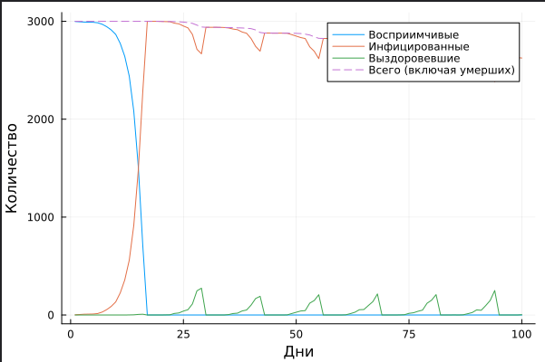

Рис

## Сканирование коэффициента заразности

- Исследуем, как изменение базовой заразности (β_und и пропорционально β_det) влияет на эпидемические показатели: пик заболеваемости, долю переболевших, число умерших. Выполняется параметрическое сканирование с несколькими повторными прогонами для учёта стохастичности.

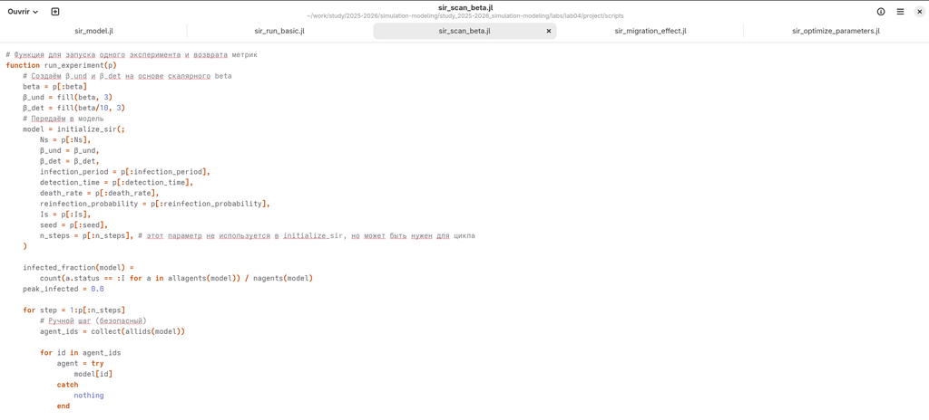

Рис

## Сканирование коэффициента заразности

- Создание файла scripts/sir_scan_beta.jl и запустим его.

[figure not shown]

Рис

## Сканирование коэффициента заразности

- График позволяет найти пороговое значение 𝛽, при котором возникает эпидемия, и оценить, как увеличивается нагрузка на систему с ростом заразности

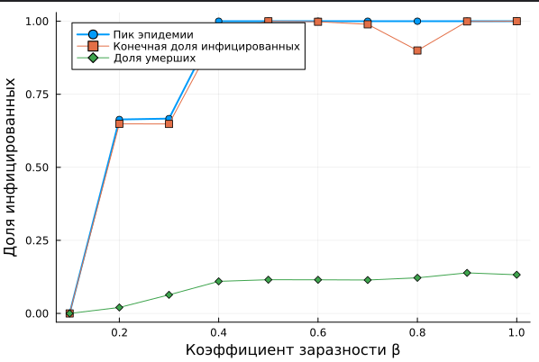

Рис

## Исследование эффекта миграции

- Исследует, как интенсивность перемещения людей между городами влияет на скорость распространения эпидемии (время достижения пика) и масштаб пика. Инфекция начинается только в одном городе, остальные изначально здоровы.

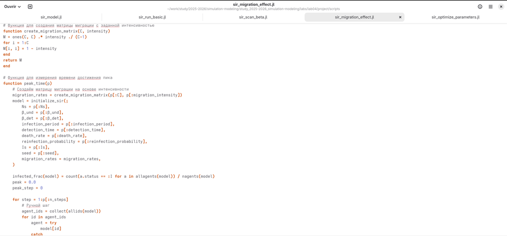

Рис

## Исследование эффекта миграции

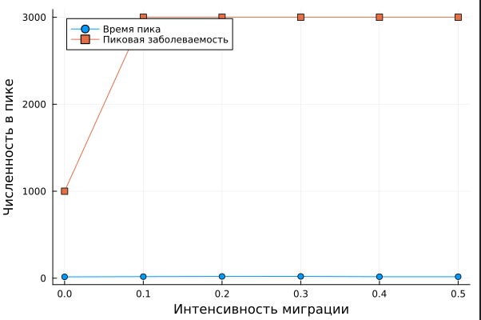

Рис

## Многокритериальная оптимизация параметров

- Ищим оптимальные комбинации параметров, минимизирующие одновременно два критерия: пиковую заболеваемость и долю умерших. Используем эволюционный алгоритм (Borg MOEA) из пакета BlackBoxOptim.

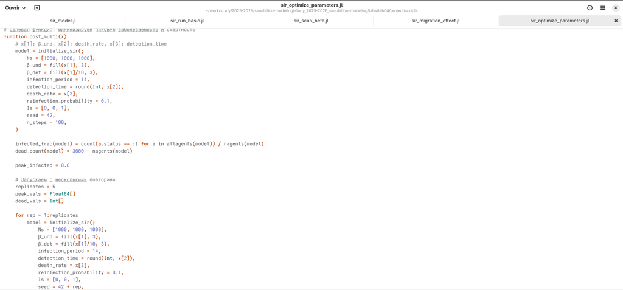

Рис

## Многокритериальная оптимизация параметров

- Создание файла scripts/sir_optimize_parameters.jl и запустим его.

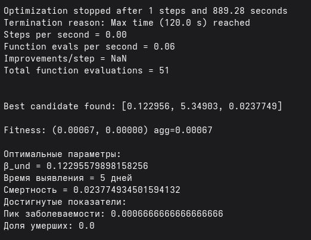

Рис

## Многокритериальная оптимизация параметров

- Вывод в консоль: оптимальные параметры и соответствующие им значения критериев.

## Сводная визуализация результатов

- Этот скрипт загружает результаты параметрического сканирования (файл data/beta_scan_all.csv, созданный scan_beta.jl) и строит единый составной график, объединяющий три панели:

— пик эпидемии и конечная доля инфицированных; — число умерших; — доля выздоровевших.

## Сводная визуализация результатов

График сохраняется как plots/comprehensive_analysis.png. Скрипт предназначен для итогового отчёта и не требует повторного запуска симуляций.

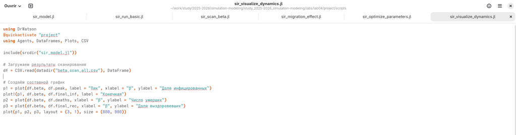

Рис

## Сводная визуализация результатов

- В консоль может выводиться дополнительная статистика (например, значения β, при которых пик превышает 5%).

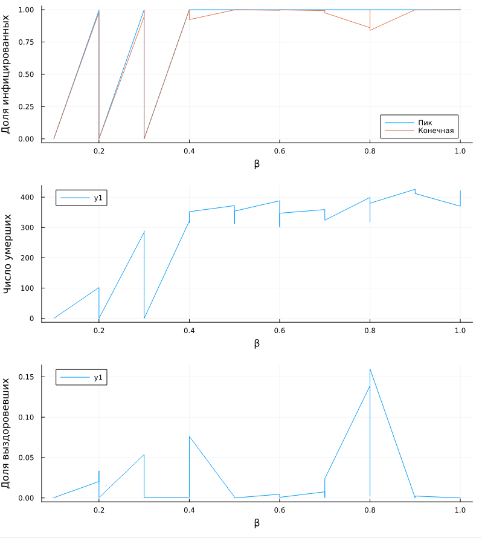

Рис

## Выводы

- Я выполнила лабораторную работу.